# Weekly Exercise 6

# Notes

As now you already are familiarized with the basics of programming in R. From now on we are going to give you more general instructions to do the exercises, instead of step by step. So that you start to make your own decisions on how to call your variables and how exactly you want to achieve the tasks.

For the following tasks, you will be asked to submit a .Rmd file, also known as “R notebook”. This code can be rendered by R into different publication formats. The upper part of this file is called “YAML header” and has some main options to render the notebook. The options in html_document: will tell R how to output the document as an HTML page (do not change that for submitting your exercises correctly).

At the end of the exercise you will find questions, for which you will need to print the answers based on your code.

For submitting the exercise check the following guidelines:

1. Change the author option “YOUR_NAME” in the upper part of this file with your name.
2. Use only the code chunks to write your code, and the bottom part to write your answers to the questions.
3. If you got slightly different plots to ours and don’t manage to get the same plot as we do, don’t frustrate and spend to much time to make it look identical. What we are most interested in is evaluating that you can do the task and that your programming logic is sound (There is also a very small chance we mess things up at some point so don’t attempt to make an identical copy of our results ;) ).
4. We ask you to store the answer to some questions in the objects `ANSWERX`; **use the code to store the answer, do not simply write the answer!**. If you do this, we will consider it WRONG!
5. DO NOT leave in the code any unnecessary code such as View() and head() that makes running and knitting the script clumsy.

# 0. Load your packages

Load the packages you will use in this section.

# 1. Data wrangling (or fixing the data)

We are going to use a dataset from the United Kingdom government. The data set describes the average weekly intake of diverse products by region. Our goal is to appreciate differences and pinpoint what are the products that are the main drive for **differences between regions**.

1. Load the tables “UK_weekFood_1.txt” and “UK_weekFood_2.txt” so that the first row in the file is the column names and that the first column is the rownames.
2. Remove the units column in both datasets.
3. Create a table that contains the data of all 13 cities, and shared food categories that are in both datasets. You could use: `intersect()`, `match()`, `[`.
4. Answer Question 1 using `setdiff()`, and store your answer in the object `ANSWER1`.

**Note: Understand what happens when you change the order of sets in the** **setdiff function**

# 2. Principal Components Analysis.

The full data with ingredients present in both files should be a dataframe that has 19 food categories, and 13 regions. This essentially is explaining 13 data points by 19 dimensions.

But we cannot easily visualize data in 19 dimensions, that is why we require mathematical tools like Principal Components Analysis (PCA) to transform the data and extract the more informative set of ‘new dimensions’, called Principal Components.

1. To be able to run the PCA, first transpose the data so that food categories are the columns. (Important as PCA runs in the columns).
2. Use the `prcomp()` function to perform a PCA on the data.
3. Plot the first two principal components of the resulting new data object.
4. Add a text label to each point by using the function `text()`, which works as plotting dots in x and y coordinates but instead of dots writes words, and its arguments `cex` [numeric], `pos` [integer 1 to 4] and `col` [color code]. The resulting plot does NOT need to look identical to the example plot, just make sure that the labels of points make sense in the position they are.
5. Answer question 2. Store your answer in the object ANSWER2.

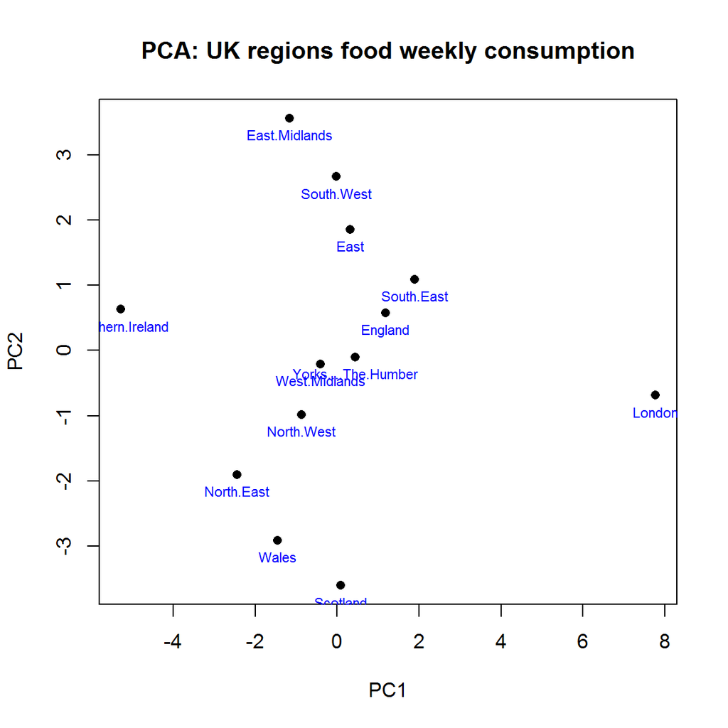

# 3. Looking for the most correlated (or anti correlated) variable

Now to understand were does most of the variability comes from we can look for the most correlated variable to the first principal component.

1. Calculate the correlation between the PC1 and each of the variables. You can calculate this with the `cor()` function.
2. Determine which is the most correlated (or anticorrelated variable). Remember use functions to make your life easier. `cor()`, `abs()`, `which.max()`, `sort()` are some examples of functions you can use to help you with this task. Store your answer to QUESTION3 in the object `ANSWER3`.
3. Plot a scatterplot of the variable you found as a function of the PC1.

Notes: Instead of “Mistery Food” as ylab, write the name of the variable you found. If you want to adjust the `blue` color use `adjustcolor()` is optional.

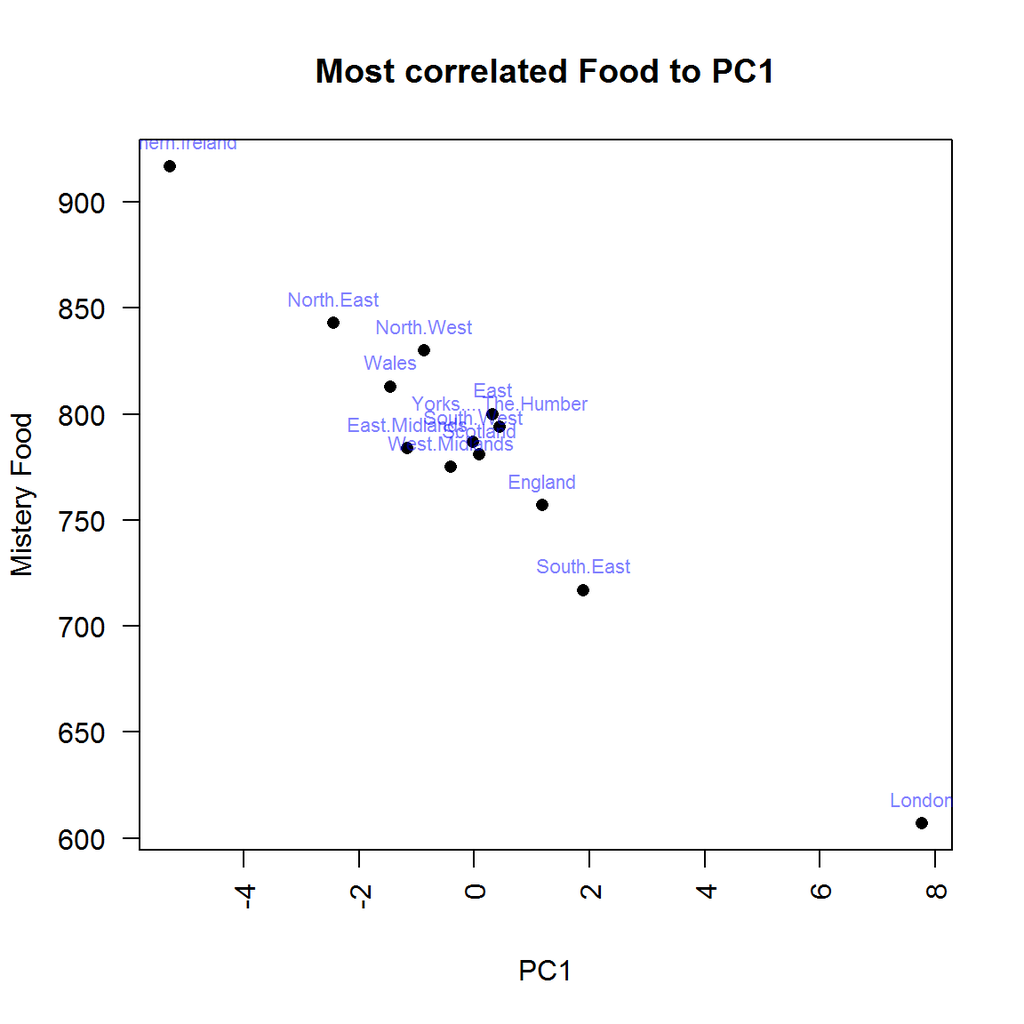

4. OPTIONAL: Try to make the same scatterplot using ggplot. If you run into trouble try to follow this [Quick guide](http://www.sthda.com/english/wiki/ggplot2-scatter-plots-quick-start-guide-r-software-and-data-visualization) to troubleshoot your issues. Additionally you can adjust the range of the axis using the `scale_x_continuous()` and `scale_y_continuous()` functions, this to show the full labels (optional).

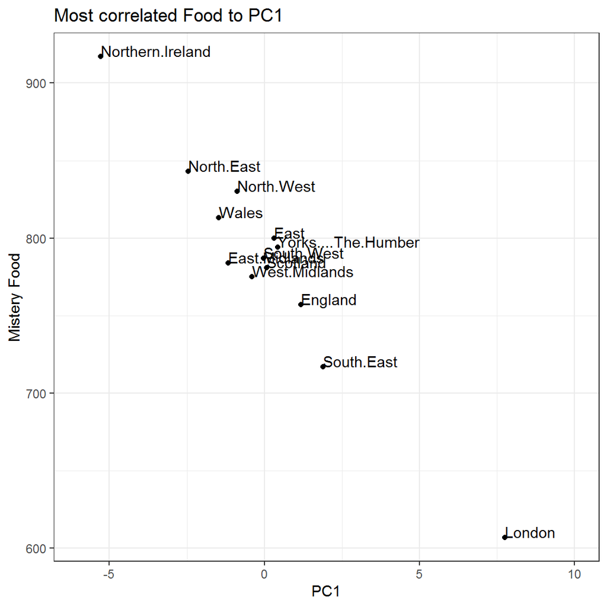

# Questions

- Q1: Which are the missing food categories?

- Q2: How much variance does the PC1 explain?

- Q3: Which food category is the most correlated to PC1?

# Credits

Authors:

- Benjamin Dubreuil
- [Miguel Angel Garcia-Campos](https://angelcampos.github.io/)
- Yaara Finkel
- Hugo Schweke

Original data from:

- UK’s government site: https://www.gov.uk/government/statistical-data-sets/family-food-datasets
- Direct link: https://assets.publishing.service.gov.uk/government/uploads/system/uploads/attachment_data/file/830364/ConsGORHH_12sep19.ods